# Linear Regression

## Introduction

- We have discussed quantifying the relationship between two continuous variables.
- Recall that the correlation describes the strength and the direction of the relationship.
  - Pearson’s correlation: describes the linear relationship; assumes normality of both variables.
  - Spearman’s correlation: describes the monotone relationship; assumes both variables are at least ordinal.
- Further, recall that correlation is *unitless* and bounded to $[-1, 1]$.

## Linear Regression: Introduction

- Now we will discuss a different way of representing/quantifying the relationship.
  - We will now construct a line of best fit, called the ordinary least squares (OLS) regression line.
- Using simple linear regression, we will model *y* (the outcome) as a function of *x* (the predictor).
  - This is called simple linear regression becaause there is only one predictor.

## Linear Regression: Definition

- **Population regression line**:

$$y = \beta_0 + \beta_1 x + \varepsilon$$

- $\beta_0$ is the $y$-intercept.
- $\beta_1$ is the slope describing the relationship between $x$ and $y$.
- $\varepsilon$ (estimated by $e$) is the error term; remember, from ANOVA (😱):

$$\varepsilon \overset{\text{iid}}{\sim} N(0, \sigma^2)$$

## Linear Regression: Definition

- **Population regression line**:

$$y = \beta_0 + \beta_1 x + \varepsilon$$

- **Sample regression line**:

$$\hat{y} = \hat{\beta}_0 + \hat{\beta}_1 x + e$$

- $\hat{y}$ estimates $y$.
- $\hat{\beta}_0$ estimates $\beta_0$.
- $\hat{\beta}_1$ estimates $\beta_1$.
- $e$ estimates $\varepsilon$.

## Linear Regression: Estimation

- We first calculate the slope, $\hat{\beta}_1$

$$\hat{\beta}_1 = \frac{\sum_{i=1}^n x_i y_i - \frac{\sum_{i=1}^n x_i \sum_{i=1}^n y_i}{n}}{\sum_{i=1}^n x_i^2 - \frac{\left(\sum_{i=1}^n x_i\right)^2}{n}} = r \frac{s_y}{s_x}$$

- $r$ is the Pearson correlation,
- $s_x$ is the standard deviation of $x$, and
- $s_y$ is the standard deviation of $y$

## Linear Regression: Estimation

- Then we can calculate the intercept, $\hat{\beta}_0$

$$\hat{\beta}_0 = \bar{y} - \hat{\beta}_1 \bar{x}$$
where

- $\bar{x}$ is the mean of $x$, and
- $\bar{y}$ is the mean of $y$.

## Linear Regression: Estimation (R)

- We will use the `linear_regression()` function from `library(ssstats)` to construct our regression model.
- In the case of simple linear regression,

```r
dataset_name %>% linear_regression(outcome = outcome_variable,
                                   function_of = predictor_variable)
```

- Peek in the future: in the case of multiple linear regression,

```r
dataset_name %>% linear_regression(outcome = outcome_variable,
                                   function_of = pred_1 + pred_2 + ... + pred_k)
```

## Linear Regression: Estimation

- Pinkie Pie suspects that Gummy enjoys snacks more the longer he chews them.
- Pinkie Pie records both the chew time (*chew_time*) and Gummy’s satisfaction level (*satisfaction*) of the last 300 snacks given to Gummy (**gummy_data**).
- Let’s now construct the simple linear regression model. How should we update the code?

```r
dataset_name %>% linear_regression(outcome = outcome_variable,
                                   function_of = predictor_variable)
```

## Linear Regression: Estimation

- Pinkie Pie suspects that Gummy enjoys snacks more the longer he chews them.
- Pinkie Pie records both the chew time (*chew_time*) and Gummy’s satisfaction level (*satisfaction*) of the last 300 snacks given to Gummy (**gummy_data**).
- Our updated code,

```r
gummy_data %>% linear_regression(outcome = satisfaction,
                                 function_of = chew_time)
```

## Linear Regression: Estimation

- Running the code,

| term | estimate | std_error | statistic | lower_bound | upper_bound | p_value |
| --- | --- | --- | --- | --- | --- | --- |
| (Intercept) | 20.9236200 | 1.09365300 | 19.13186 | 18.7713585 | 23.0758815 | < 0.001 |
| chew_time | 0.8994515 | 0.03052707 | 29.46407 | 0.8393756 | 0.9595275 | < 0.001 |

- The resulting model is

$$\hat{\text{satisfaction}} = 20.92 + 0.90 \text{ chew\_time}$$

## Linear Regression: Interpretations

- **Interpretation of the slope, $\hat{\beta}_1$**
  - For a [$k$] [units of *x*] increase in [*x*], we expect [*y*] to [increase or decrease] by [$k \times |\hat{\beta}_1|$] [units of *y*].
- **Interpretation of the $y$-intercept, $\hat{\beta}_0$**
  - When [*x*] is 0, we expect the mean of [*y*] to be [$\hat{\beta}_0$].
  - Caveat:
    - It does not always make sense for *x* = 0. In this situation, we do not interpret the *y*-intercept.
    - Some applications (e.g., psychology) will center the $x$ variable around its mean.
      - Then, when *x* = 0, we are interpreting in terms of the “average value of *x*.”

## Linear Regression: Interpretations

- Recall the regression line we constructed,

$$\hat{\text{satisfaction}} = 20.92 + 0.90 \text{ chew\_time}$$

- What is the iterpretation for the slope of time chewed?
  - For a 1 minute increase in time chewed, the satisfaction Gummy feels increases by 0.9 points.
- What is the interpretation of the *y*-intercept?
  - Gummy’s base level of satisfaction is 20.9.

## Linear Regression: Multiple Predictors!

- We have learned simple linear regression,

$$y = \beta_0 + \beta_1 x + \varepsilon$$

- Now, we expand to multiple regression, which allows us to include multiple predictors,

$$y = \beta_0 + \beta_1 x_1 + \beta_2 x_2 + ... + \beta_k x_k + \varepsilon$$

- Note: simple linear regression is just a special case of multiple regression, where $k=1$.

## Linear Regression: Estimation (R)

- We will use the `linear_regression()` function from `library(ssstats)` to construct our regression model.
- In the case of multiple linear regression,

```r
dataset_name %>% linear_regression(outcome = outcome_variable,
                                   function_of = pred_1 + pred_2 + ... + pred_k)
```

## Linear Regression: Estimation

- Pinkie Pie suspects that Gummy enjoys snacks more the longer he chews them. She also suspects that crunch factor plays a role in his satisfaction and now wants to incorporate this into the analysis.
- Pinkie Pie records the chew time (*chew_time*), the crunch factor (*snack_crunch*) and Gummy’s satisfaction level (*satisfaction*) of the last 300 snacks given to Gummy (**gummy_data**).
- Let’s now construct the corresponding multiple regression model. How should we update the code?

```r
dataset_name %>% linear_regression(outcome = outcome_variable,
                                   function_of = pred_1 + pred_2 + ... + pred_k)
```

## Linear Regression: Estimation

- Pinkie Pie suspects that Gummy enjoys snacks more the longer he chews them. She also suspects that crunch factor plays a role in his satisfaction and now wants to incorporate this into the analysis.
- Pinkie Pie records the chew time (*chew_time*), the crunch factor (*snack_crunch*) and Gummy’s satisfaction level (*satisfaction*) of the last 300 snacks given to Gummy (**gummy_data**).
- Our updated code,

```r
gummy_data %>% linear_regression(outcome = satisfaction,
                                 function_of = chew_time + snack_crunch)
```

## Linear Regression: Estimation

- Running the code,

| term | estimate | std_error | statistic | lower_bound | upper_bound | p_value |
| --- | --- | --- | --- | --- | --- | --- |
| (Intercept) | 23.0169700 | 4.92867699 | 4.6700098 | 13.3174149 | 32.7165251 | < 0.001 |
| chew_time | 0.9183209 | 0.05301652 | 17.3214114 | 0.8139853 | 1.0226566 | < 0.001 |
| snack_crunch | -0.0406172 | 0.09324032 | -0.4356184 | -0.2241126 | 0.1428782 | 0.663 |

- The resulting model is

$$\hat{\text{satisfaction}} = 23.02 + 0.92 \text{ chew\_time} - 0.04 \text{ snack\_crunch}$$

## Linear Regression: Interpretations

- **Interpretation of the slope, $\hat{\beta}_1$**
  - For a [$k$] [units of *x*] increase in [*x*], we expect [*y*] to [increase or decrease] by [$k \times |\hat{\beta}_1|$] [units of *y*], after adjusting for all other predictors in the model.
- **Interpretation of the $y$-intercept, $\hat{\beta}_0$**
  - When all predictors are set to 0, we expect the mean of [*y*] to be [$\hat{\beta}_0$].
  - Caveat:
    - It definitely does not always make sense for all *x* = 0. In this situation, we do not interpret the *y*-intercept.
    - Centering still applies here.

## Linear Regression: Interpretations

- Recall the regression line we constructed,

$$\hat{\text{satisfaction}} = 23.02 + 0.92 \text{ chew\_time} - 0.04 \text{ snack\_crunch}$$

## Estimation: Confidence Interval for $\beta_i$

- Like all statistics, we can put a confidence interval on $\beta_i$.
  - When reporting regression results, I *always* include the corresponding CI.

$$\hat{\beta}_i \pm t_{\alpha/2, n-k-1} \text{ SE}_{\hat{\beta}_i}$$

- *This is default output in our `linear_regression()` function.*

## Estimation: Confidence Interval for $\beta_i$

- Looking at our output,

| term | estimate | std_error | statistic | lower_bound | upper_bound | p_value |
| --- | --- | --- | --- | --- | --- | --- |
| (Intercept) | 23.0169700 | 4.92867699 | 4.6700098 | 13.3174149 | 32.7165251 | < 0.001 |
| chew_time | 0.9183209 | 0.05301652 | 17.3214114 | 0.8139853 | 1.0226566 | < 0.001 |
| snack_crunch | -0.0406172 | 0.09324032 | -0.4356184 | -0.2241126 | 0.1428782 | 0.663 |

- The 95% CI for $\beta_{\text{time chewed}}$ is $(0.81, 1.02)$.
- The 95% CI for $\beta_{\text{crunch factor}}$ is $(-0.22, 0.14)$.

## Estimation: Confidence Interval for $\beta_i$

- What if we want something other than a 95% CI?

```r
gummy_data %>% linear_regression(outcome = satisfaction,
                                 function_of = chew_time + snack_crunch,
                                 confidence = 0.99)
```

## Estimation: Confidence Interval for $\beta_i$

- What if we want something other than a 95% CI?

| term | estimate | std_error | statistic | lower_bound | upper_bound | p_value |
| --- | --- | --- | --- | --- | --- | --- |
| (Intercept) | 23.0169700 | 4.92867699 | 4.6700098 | 10.2394540 | 35.7944861 | < 0.001 |
| chew_time | 0.9183209 | 0.05301652 | 17.3214114 | 0.7808764 | 1.0557654 | < 0.001 |
| snack_crunch | -0.0406172 | 0.09324032 | -0.4356184 | -0.2823412 | 0.2011068 | 0.663 |

## Hypothesis Testing: Significance of $\beta_i$

- **Hypotheses**
  - $H_0: \ \beta_i = 0$
  - $H_1: \ \beta_i \ne 0$
- **Test Statistic**
  - $t_0 = \frac{\hat{\beta}_i}{s_{\hat{\beta}_i}} = \frac{\hat{\beta}_i}{\text{SE of }\hat{\beta}_i}$
- *p*-Value
  - $p = 2 \times P[t_{n-k-1} \ge |t_0|]$
- *This is default output in our `linear_regression()` function.*

## Hypothesis Testing: Significance of $\beta_i$

- Pinkie Pie suspects that Gummy enjoys snacks more the longer he chews them. She also suspects that crunch factor plays a role in his satisfaction and now wants to incorporate this into the analysis.
- Pinkie Pie records the chew time (*chew_time*), the crunch factor (*snack_crunch*) and Gummy’s satisfaction level (*satisfaction*) of the last 300 snacks given to Gummy (**gummy_data**).

| term | estimate | std_error | statistic | lower_bound | upper_bound | p_value |
| --- | --- | --- | --- | --- | --- | --- |
| (Intercept) | 23.0169700 | 4.92867699 | 4.6700098 | 13.3174149 | 32.7165251 | < 0.001 |
| chew_time | 0.9183209 | 0.05301652 | 17.3214114 | 0.8139853 | 1.0226566 | < 0.001 |
| snack_crunch | -0.0406172 | 0.09324032 | -0.4356184 | -0.2241126 | 0.1428782 | 0.663 |

## Hypothesis Testing: Significance of $\beta_i$

- **Hypotheses**
  - $H_0: \ \beta_{\text{chew\_time}} = 0$
  - $H_1: \ \beta_{\text{chew\_time}} \ne 0$
- **Test Statistic and *p*-Value**
  - $t_0 = 17.32$; $p < 0.001$
- **Rejection Region**
  - Reject $H_0$ if $p<\alpha$; $\alpha=0.05$
- **Conclusion and Intepretation**
  - Reject $H_0$. There is sufficient evidence to suggest that the slope of time chewed is non-zero.

## Hypothesis Testing: Significance of $\beta_i$

- **Hypotheses**
  - $H_0: \ \beta_{\text{snack\_crunch}} = 0$
  - $H_1: \ \beta_{\text{snack\_crunch}} \ne 0$
- **Test Statistic and *p*-Value**
  - $t_0 = -0.44$; $p = 0.663$
- **Rejection Region**
  - Reject $H_0$ if $p<\alpha$; $\alpha=0.05$
- **Conclusion and Intepretation**
  - Fail to reject $H_0$. There is not sufficient evidence to suggest that the slope of crunch factor is non-zero.

## Reporting Linear Regression Results

- How do I report regression models in the real world?
  - I always give a table of $\hat{\beta}_i$, (95% CI), and $p$-values.
- In our example,

| Predictor | Estimate (95% CI) | *p*-Value |
| --- | --- | --- |
| Time Chewed | 0.92 (0.81, 1.02) | < 0.001 |
| Crunch Factor | -0.04 (-0.22, 0.14) | 0.663 |

## Hypothesis Testing: Significant Regression Line

- We can use the likelihood ratio test to test for a “significant regression” line.
  - A significant regression line means that there is a non-zero slope among all slopes.
- **Hypotheses**
  - $H_0: \ \beta_1 = ... = \beta_k = 0$
  - $H_1:$ at least one is different
- **Test Statistic and *p*-Value**
  - $\chi^2_0$ (from R)
  - $p = \text{P}[\chi^2_{k} \ge \chi^2_0]$

## Hypothesis Testing: Significant Regression Line (R)

- We will use the `significant_line()` function from `library(ssstats)` to test for a significant model.

```r
dataset_name %>% significant_line(outcome = outcome_variable,
                                  function_of = pred_1 + pred_2 + ... + pred_k)
```

## Hypothesis Testing: Significant Regression Line

- Pinkie Pie suspects that Gummy enjoys snacks more the longer he chews them. She also suspects that crunch factor plays a role in his satisfaction and now wants to incorporate this into the analysis.
- Pinkie Pie records the chew time (*chew_time*), the crunch factor (*snack_crunch*) and Gummy’s satisfaction level (*satisfaction*) of the last 300 snacks given to Gummy (**gummy_data**).
- Let’s now determine if we have a significant regression line. How should we update the following code?

```r
dataset_name %>% significant_line(outcome = outcome_variable,
                                  function_of = pred_1 + pred_2 + ... + pred_k)
```

## Hypothesis Testing: Significant Regression Line

- Pinkie Pie suspects that Gummy enjoys snacks more the longer he chews them. She also suspects that crunch factor plays a role in his satisfaction and now wants to incorporate this into the analysis.
- Pinkie Pie records the chew time (*chew_time*), the crunch factor (*snack_crunch*) and Gummy’s satisfaction level (*satisfaction*) of the last 300 snacks given to Gummy (**gummy_data**).
- Let’s now determine if we have a significant regression line. Our updated code,

```r
gummy_data %>% significant_line(outcome = satisfaction,
                                function_of = chew_time + snack_crunch)
```

## Hypothesis Testing: Significant Regression Line

- Running the code,

```r
gummy_data %>% significant_line(outcome = satisfaction,
                                function_of = chew_time + snack_crunch)
```

```
Likelihood Ratio Test for Significant Regression Line:
Null: H₀: β₁ = β₂ = ... = βₖ = 0
Alternative: H₁: At least one βᵢ ≠ 0
Test statistic: χ²(2) = 57158.677
p-value: p < 0.001
Conclusion: Reject the null hypothesis (p = < 0.001 < α = 0.05)
```

## Hypothesis Testing: Significant Regression Line

- **Hypotheses**
  - $H_0: \ \beta_1 = \beta_2 = 0$
  - $H_1:$ at least one is different
- **Test Statistic and *p*-Value**
  - $\chi^2_0 = 57158.7$; $p < 0.001$.
- **Rejection Region**
  - Reject $H_0$ if $p < \alpha$; $\alpha = 0.05$.
- **Conclusion and Intepretation**
  - Reject $H_0$. There is sufficient evidence to suggest that at least one slope is non-zero.

## Line Fit: $R^2$

- We can assess how well the regression model fits the data using $R^2$.

$$R^2 = \frac{\text{SS}_{\text{Reg}}}{\text{SS}_{\text{Tot}}}$$

- Thus, $R^2$ is the *proportion of variation* explained by the model (i.e., predictor set).
- $R^2 \in [0, 1]$
  - $R^2 \to 0$ indicates that the model fits “poorly.”
  - $R^2 \to 1$ indicates that the model fits “well.”
  - $R^2 = 1$ indicates that all points fall on the response surface.

## Line Fit: $R^2$

- Recall that the error term in ANOVA is the “catch all” …
  - The SS<sub>Tot</sub> is constant for the outcome of interest.
  - As we add predictors to the model, we are necessarily increasing SS<sub>Reg</sub>
    - The variance is moving from SS<sub>E</sub> to SS<sub>Reg</sub>
- We do not want to arbitrarily increase $R^2$, so we will use an adjusted version:

$$R^2_{\text{adj}} = 1 - \frac{\text{MS}_{\text{E}}}{\text{SS}_{\text{Tot}}/\text{df}_{\text{Tot}}}$$

## Line Fit: $R^2$ (R)

- We will use the `r_squared`()`function from`library(ssstats)` to find the $R^2$ value.

```r
dataset_name %>% r_squared(outcome = outcome_variable,
                           function_of = pred_1 + pred_2 + ... + pred_k)
```

## Line Fit: $R^2$

- Pinkie Pie suspects that Gummy enjoys snacks more the longer he chews them. She also suspects that crunch factor plays a role in his satisfaction and now wants to incorporate this into the analysis.
- Pinkie Pie records the chew time (*chew_time*), the crunch factor (*snack_crunch*) and Gummy’s satisfaction level (*satisfaction*) of the last 300 snacks given to Gummy (**gummy_data**).
- Let’s now find the $R^2$ value for the model we constructed earlier. How should we update the following code?

```r
dataset_name %>% r_squared(outcome = outcome_variable,
                           function_of = pred_1 + pred_2 + ... + pred_k)
```

## Line Fit: $R^2$

- Pinkie Pie suspects that Gummy enjoys snacks more the longer he chews them. She also suspects that crunch factor plays a role in his satisfaction and now wants to incorporate this into the analysis.
- Pinkie Pie records the chew time (*chew_time*), the crunch factor (*snack_crunch*) and Gummy’s satisfaction level (*satisfaction*) of the last 300 snacks given to Gummy (**gummy_data**).
- Our updated code,

```r
gummy_data %>% r_squared(outcome = satisfaction,
                         function_of = chew_time + snack_crunch)
```

## Line Fit: $R^2$

- Pinkie Pie records the chew time (*chew_time*), the crunch factor (*snack_crunch*) and Gummy’s satisfaction level (*satisfaction*) of the last 300 snacks given to Gummy (**gummy_data**).
- Running the code,

```r
gummy_data %>% r_squared(outcome = satisfaction,
                         function_of = chew_time + snack_crunch)
```

```
[1] 0.7429
```

- Time chewed and crunch factor together account for 74.3% of the variability in Gummy’s satisfaction.

## Visualizing the Model

- Visualizing the resulting model is difficult with multiple predictors.
  - *y*-axis: outcome variable
  - *x*-axis: one predictor variable
    - We will allow only one predictor variable to vary.
    - That is, we will plug in for all *x* except one, which will be on the *x*-axis.
      - My go to for continuous *x*: the median of the *x*.

## Visualizing the Model

- Recall our example,

$$\hat{\text{satisfaction}} = 23.02 + 0.92 \text{ chew\_time} - 0.04 \text{ snack\_crunch}$$

- Our graph will have:
  - *satisfaction* on the *y*-axis
  - **either** *chew_time* or *snack_crunch* on the *x*-axis.
    - Which ever is *not* on the *x*-axis will be held constant.

## Visualizing the Model

- To create predicted values, we are going to *modify* the dataset.

```r
dataset_name <- dataset_name %>%
  mutate(variable_on_x = b_0 + b_1*x_1 + ... + b_k*x_k)
```

- Note that we will *plug in* for all *x* except one, which will vary & is on the *x*-axis.
- Let’s say we have 3 predictors: *x*<sub>1</sub>, *x*<sub>2</sub>, and *x*<sub>3</sub>.
- If we want *x*<sub>1</sub> on the *x*-axis, then

```r
dataset_name <- dataset_name %>%
  mutate(variable_on_x = b_0 + b_1*x_1 + b_2*median(x_2) + b_3*median(x_3))
```

$$\text{variable on } x = \hat{\beta}_0 + \hat{\beta}_1 x_1 + \hat{\beta}_2 \text{median}(x_2) + \hat{\beta}_3 \text{median}(x_3)$$

## Visualizing the Model

- For our example, we will create two visualizations: one with *chew_time* on the *x*-axis and one with *snack_crunch* on the *x*-axis.

```r
gummy_data <- gummy_data %>%
  mutate(chew_on_x = 23.02 + 0.92 * chew_time - 0.04 * median(snack_crunch, na.rm = TRUE),
         snack_on_x = 23.02 + 0.92 * median(chew_time, na.rm = TRUE) - 0.04 * snack_crunch)
```

| satisfaction | chew_on_x | snack_on_x |
| --- | --- | --- |
| 50.70824 | 36.32793 | 51.06114 |
| 55.13960 | 57.84485 | 50.72415 |
| 58.10416 | 44.06215 | 51.18664 |

## Visualizing the Model

- To visualize our model, we will *overlay* the regression line on a scatter plot of the data.
- Here, we take the scatterplot code from last week and add a `geom_line()` for the regression line.

```r
dataset_name %>% ggplot(aes(x = x_variable, y = y_variable)) + # specify x and y
  geom_point(size = 2.5, color = "gray50") + # plot points
  geom_line(aes(y = line_variable), size = 1, color = "black") + # plot line
  labs(x = "x-axis label", # edit x-axis label
       y = "y-axis label") + # edit y-axis label
  theme_bw() # change theme of graph
```

## Visualizing the Model

- For our example, we will create two visualizations: one with *chew_time* on the *x*-axis and one with *snack_crunch* on the *x*-axis.
- The base code for the visualization is:

```r
gummy_data %>% ggplot(aes(x = x_variable, y = satisfaction)) + # specify x and y
  geom_point(size = 2.5, color = "gray50") + # plot points
  geom_line(aes(y = line_variable), size = 1, color = "black") + # plot line
  labs(x = "x-axis label", # edit x-axis label
       y = "Gummy's Satisfaction") + # edit y-axis label
  theme_bw() # change theme of graph
```

## Visualizing the Model

- The code for the visualization with *chew_time* on the *x*-axis,

```r
gummy_data %>% ggplot(aes(x = chew_time, y = satisfaction)) + # specify x and y
  geom_point(size = 2.5, color = "gray50") + # plot points
  geom_line(aes(y = chew_on_x), size = 1, color = "black") + # plot line
  labs(x = "Time Spent Chewing (min)", # edit x-axis label
       y = "Gummy's Satisfaction") + # edit y-axis label
  theme_bw() # change theme of graph
```

## Visualizing the Model

- The visualization with *chew_time* on the *x*-axis,

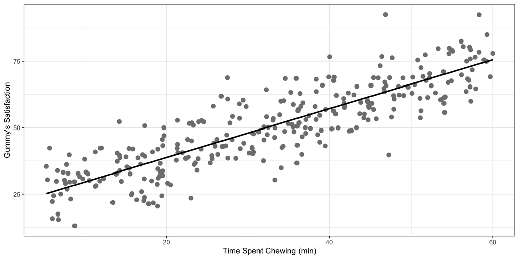

## Visualizing the Model

- The code for the visualization with *snack_crunch* on the *x*-axis,

```r
gummy_data %>% ggplot(aes(x = snack_crunch, y = satisfaction)) + # specify x and y
  geom_point(size = 2.5, color = "gray50") + # plot points
  geom_line(aes(y = snack_on_x), size = 1, color = "black") + # plot line
  labs(x = "Crunch Factor of Snack", # edit x-axis label
       y = "Gummy's Satisfaction") + # edit y-axis label
  theme_bw() # change theme of graph
```

## Visualizing the Model

- The visualization with *snack_crunch* on the *x*-axis,

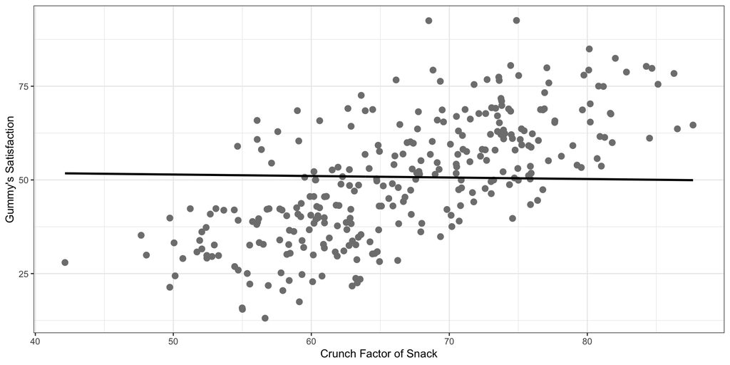

## Visualizing the Model

- Whoa! It looks like there is not much of a relationship between crunch factor and satisfaction!
- Remember that regression is looking at the relationship between *y* and *x*<sub>*i*</sub> while **adjusting** for all other predictors in the model.
  - The variability in *satisfaction* explained by *snack_crunch* is being adjusted for *chew_time*.
  - This is why we saw a non-significant slope for *snack_crunch* earlier.
  - This means that *chew_time* explains the variance in *satisfaction*, not *snack_crunch*.

## Visualizing the Model

- Hm… let’s look at the correlation:

```r
gummy_data %>% correlation(x = snack_crunch, y = chew_time,
                           method = "spearman")
```

|  | var1 | var2 | correlation | test_statistic | p_value |
| --- | --- | --- | --- | --- | --- |
| 1 | snack_crunch | chew_time | 0.817 | 822660 | < 0.001 |

- With $r_s = 0.82$, we see that *snack_crunch* and *chew_time* are **highly correlated**.
  - One is predicting the other! We should not include both in the model.

## Wrap Up

- This is just scratching the surface for multiple regression.
- Other statistics courses go deeper into regression topics.
  - Categorical predictors.
  - Interaction terms.
  - Regression diagnostics.
  - How to handle non-continuous outcomes.
  - Advanced data visualization for models.